# Let’s see what the MUTE and SPEECHLESS bait, CATCHES

Ann Loraine and Diego Lopez

2023-12-09

## Introduction

This project is a continuation from Ann Loraine findings that two genes were found to have a correlation coefficient of 0.49 that are required to form stomata in the leaves of Arabidopsis thaliana plants:

The pair is:

- [AT5G53210](https://www.arabidopsis.org/servlets/TairObject?name=AT5G53210&type=locus) (gene symbol SPEECHLESS)
- [AT3G06120](https://www.arabidopsis.org/servlets/TairObject?name=AT3G06120&type=locus) (gene symbol MUTE)

These genes are involved in the same processes and such genes typically exhibit similar expression patterns, which enables us to identify other genes involved the same process.

In this Markdown, we use a large expression data set to answer the question:

- Are any more genes involved in stomatal formation and can we identify those genes?

Since the two genes have a relativly strong correlation coefficient of 0.49. We can compare expression of MUTE and SPEECHLESS to other genes in the genome, and identify those genes, if any, that are highly correlated with both MUTE and SPEECHLESS and therefore would be likely candidates for genes involved in stomatal formation.

TLDR: This pair of genes should help us find genes are are involved in, and required for, formation of stomata during leaf development. Let’s find out if it can!

### About the data

The data were taken from the Gene Expression Omnibus and processed by Ann Loraine. Data files were downloaded from GEO and re-processed using algorithms standard in the field.

Data are available from the following publicly accessible URL:

```r
data_file_url = "https://uncc.instructure.com/courses/176579/files/18867927/download"
```

## Results

Download the data file to our local computer:

```r
fname="expression_data.txt.gz"
if (!file.exists(fname)) {
  download.file(data_file_url,fname,mode="wb")
}
```

Note that on Windows systems, we need `mode` to be set to `wb` to ensure that the file will be available for reading in the next step.

Read the data file into memory:

```r
df = read.table(fname, header = T, sep = "\t")
```

The data frame contains 500 columns and 20922 rows.

Rows are named for Arabidopsis gene names. The column names correspond to individual samples from the Gene Expression Omnibus. Each row contains expression values for the gene in that row. This sounds rather complex, let’s try to mine the data.

## Compute Correlation Coefficients:

```r
# Compute Pearson's correlation coefficients
cor_matrix <- cor(df)
```

Let’s create a histogram showing the distribution of Pearson’s correlation coefficients across all 500 samples.

To begin lets put the genes MUTE and SPEECHLESS into their own variables.

```r
mute <- "AT3G06120"
speechless <- "AT5G53210"
```

Using the gene names we can begin extracting the correlation coefficients for the genes MUTE and SPEECHLESS from the correlation matrix.

```r
cor_mute <- cor_matrix[mute, drop = FALSE]
cor_speechless <- cor_matrix[speechless, drop = FALSE]
```

Finally we can print out the data.

```r
cor_mute
```

```
## [1] NA
```

```r
cor_speechless
```

```
## [1] NA
```

Hmm that doesn’t seem to be working…lets try somthing else.

## Results

We first create the vector for the histogram:

```r
cor_vector <- as.vector(cor_matrix)
```

Now we can declare the histogram like so:

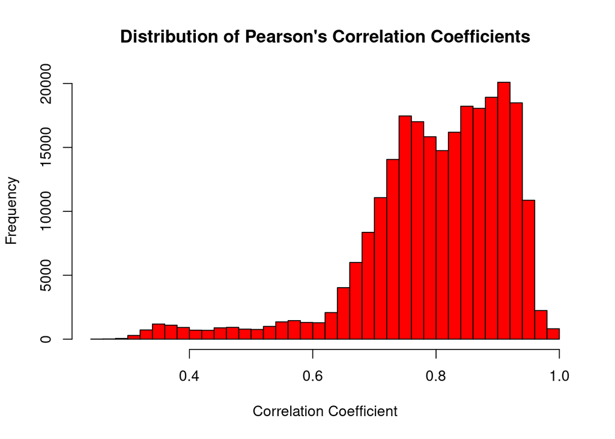

```r
hist(cor_vector, main = "Distribution of Pearson's Correlation Coefficients",
     xlab = "Correlation Coefficient", ylab = "Frequency", col = "red", border = "black", breaks = 40)
```

Great that worked! Lets try to isolate those candidate genes…

## Highly Correlated Genes

Based on the correlation threshold of 0.5, lets try to show which of the genes are identified as highly correlated with both MUTE and SPEECHLESS:

We’ll start by saving the threshold to a variable

```r
threshold <- 0.5
```

Next, we can use the absolute values of both the correlaction coefficients for the MUTE and SPEECHLESS genes. The absolute value of the correlation coefficient for the two genes must greater than the threshold.

We can use greater than (>) with the and (&) symbols to create the logic all in one line like so:

```r
highly_correlated_genes <-names(which(abs(cor_mute) > threshold & abs(cor_speechless) > threshold))
```

Now let’s print the result!

```r
highly_correlated_genes
```

[output not shown]

Well, that didn’t work…hmm I wonder what happened?

## Discussion

The analysis was supposed to identify a set of genes that are highly correlated with both MUTE and SPEECHLESS but was rather unsuccessful. Those genes would be potential candidates for further investigation, as they may play a role in the stomatal.

The next steps in this study would involve exploring the biological functions of identified candidate genes (if we could have isolated them), then conducting more experiments to discover their role in stomatal development.